# L05-2-Grouping

## Count()

Counts/tally observations by group. tally is a convenient wrapper for summarize that will either call n or sum(n) depending on whether you're tallying for the first time, or re-tallying. count() is similar, but also does the group_by for you.

### Usage

count(x, ..., wt = NULL, sort = FALSE)

```r
# View help on count
#?count
count(mpg, class, sort = TRUE)
```

| class | n |
| --- | --- |
| suv | 62 |
| compact | 47 |
| midsize | 41 |
| subcompact | 35 |
| pickup | 33 |
| minivan | 11 |
| 2seater | 5 |

```r
# Display the distinct values of mpg$class and row count
# Use count()
# Sort results, largest first
mpg %>% count(class, sort = TRUE)
```

| class | n |
| --- | --- |
| suv | 62 |
| compact | 47 |
| midsize | 41 |
| subcompact | 35 |
| pickup | 33 |
| minivan | 11 |
| 2seater | 5 |

Summarize the mpg data to have min, max and mean highway miles per gallon by class

```r
mpg %>% group_by(class) %>%
        summarize(min = min(hwy),
                  avg = mean(hwy),
                  max = max(hwy))
```

| class | min | avg | max |
| --- | --- | --- | --- |
| 2seater | 23 | 24.80000 | 26 |
| compact | 23 | 28.29787 | 44 |
| midsize | 23 | 27.29268 | 32 |
| minivan | 17 | 22.36364 | 24 |
| pickup | 12 | 16.87879 | 22 |
| subcompact | 20 | 28.14286 | 44 |
| suv | 12 | 18.12903 | 27 |

```r
# Transform mpg into
# Columns: class, hwy_max, hwy_avg, hwy_min
# where max, avg, and min are summaries of hwy
# grouped by class
# source: mpg
# result: df
df <- mpg %>% group_by(class) %>%
   summarize(hwy_max = hwy %>% max(),
            hwy_avg = hwy %>% mean(),
            hwy_min = hwy %>% min()) %>%
    arrange(desc(hwy_max))

# glimpse result
#df %>% glimpse()

# display result
df
```

| class | hwy_max | hwy_avg | hwy_min |
| --- | --- | --- | --- |
| compact | 44 | 28.29787 | 23 |
| subcompact | 44 | 28.14286 | 20 |
| midsize | 32 | 27.29268 | 23 |
| suv | 27 | 18.12903 | 12 |
| 2seater | 26 | 24.80000 | 23 |
| minivan | 24 | 22.36364 | 17 |
| pickup | 22 | 16.87879 | 12 |

Notice there is one row per unique class. Also notice hwy_min and hwy_max are integers while hwy_avg is a double.

Next: Gather hwy_min, hwy_max, hwy_avg into name / value pair columns.

```r
df %>% gather(key = hwy_metric, value = hwy_value, 2:4)
```

| class | hwy_metric | hwy_value |
| --- | --- | --- |
| compact | hwy_max | 44.00000 |
| subcompact | hwy_max | 44.00000 |
| midsize | hwy_max | 32.00000 |
| suv | hwy_max | 27.00000 |
| 2seater | hwy_max | 26.00000 |
| minivan | hwy_max | 24.00000 |
| pickup | hwy_max | 22.00000 |
| compact | hwy_avg | 28.29787 |
| subcompact | hwy_avg | 28.14286 |
| midsize | hwy_avg | 27.29268 |
| suv | hwy_avg | 18.12903 |
| 2seater | hwy_avg | 24.80000 |
| minivan | hwy_avg | 22.36364 |
| pickup | hwy_avg | 16.87879 |
| compact | hwy_min | 23.00000 |
| subcompact | hwy_min | 20.00000 |
| midsize | hwy_min | 23.00000 |
| suv | hwy_min | 12.00000 |
| 2seater | hwy_min | 23.00000 |
| minivan | hwy_min | 17.00000 |
| pickup | hwy_min | 12.00000 |

```r
# Gather hwy_min, hwy_max, hwy_avg into
# hwy_metric and hwy_value columns
# source: df
# result: df2
# Hint: gather()
df2 <- df %>%
    gather(key = hwy_metric, value = hwy_value, 2:4)

# display result
df2
```

| class | hwy_metric | hwy_value |
| --- | --- | --- |
| compact | hwy_max | 44.00000 |
| subcompact | hwy_max | 44.00000 |
| midsize | hwy_max | 32.00000 |
| suv | hwy_max | 27.00000 |
| 2seater | hwy_max | 26.00000 |
| minivan | hwy_max | 24.00000 |
| pickup | hwy_max | 22.00000 |
| compact | hwy_avg | 28.29787 |
| subcompact | hwy_avg | 28.14286 |
| midsize | hwy_avg | 27.29268 |
| suv | hwy_avg | 18.12903 |
| 2seater | hwy_avg | 24.80000 |
| minivan | hwy_avg | 22.36364 |
| pickup | hwy_avg | 16.87879 |
| compact | hwy_min | 23.00000 |
| subcompact | hwy_min | 20.00000 |
| midsize | hwy_min | 23.00000 |
| suv | hwy_min | 12.00000 |
| 2seater | hwy_min | 23.00000 |
| minivan | hwy_min | 17.00000 |
| pickup | hwy_min | 12.00000 |

Notice the prior columns are gone and hwy_metric and hwy_value took their place. The number of rows increased as a result of the gather() operation.

Next: Remove the hwy_ prefix from hwy_metric column

```r
# Remove the hwy_ prefix from hwy_metric column
# Store result in df3
# Hint: str_replace()
df3 <- df2 %>%
   mutate(hwy_metric = hwy_metric %>% str_replace("hwy_", ""))

# Display result
df3
```

| class | hwy_metric | hwy_value |
| --- | --- | --- |
| compact | max | 44.00000 |
| subcompact | max | 44.00000 |
| midsize | max | 32.00000 |
| suv | max | 27.00000 |
| 2seater | max | 26.00000 |
| minivan | max | 24.00000 |
| pickup | max | 22.00000 |
| compact | avg | 28.29787 |
| subcompact | avg | 28.14286 |
| midsize | avg | 27.29268 |
| suv | avg | 18.12903 |
| 2seater | avg | 24.80000 |
| minivan | avg | 22.36364 |
| pickup | avg | 16.87879 |
| compact | min | 23.00000 |
| subcompact | min | 20.00000 |
| midsize | min | 23.00000 |
| suv | min | 12.00000 |
| 2seater | min | 23.00000 |
| minivan | min | 17.00000 |
| pickup | min | 12.00000 |

Notice the values of hwy_metric do not contain `hwy__` anymore.

Next: Plot all metrics

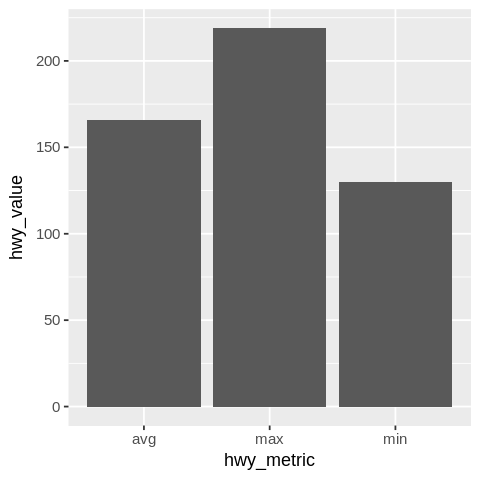

```r
# Plot min, max, and avg
# Hint: geom_col()
library(repr)
  options(repr.plot.width=4, repr.plot.height=4)

df3 %>%
   ggplot(aes(hwy_metric, hwy_value))  +
      geom_col()
```

Notice the order is avg, max, and then min. It would make more sense to order them min, avg, then max.

Next: Convert hwy_metric to a factor then order the levels.

```r
# Convert hwy_metric to a factor
# Store result in df4
# Hint: as.factor()
df4 <- df3 %>%
   mutate(hwy_metric = hwy_metric %>% as.factor())

# Display the levels and row count
# Hint: fct_count()
df4$hwy_metric %>% fct_count()

# Reorder the levels
# min, avg, max
# update df4
# Hint: fct_relevel()
df4 <- df4 %>%
   mutate(hwy_metric = hwy_metric %>% fct_relevel(c("min", "avg", "max")))

# Display the levels and row count
# Hint: fct_count()
df4$hwy_metric %>% fct_count()
```

| f | n |
| --- | --- |
| avg | 7 |
| max | 7 |
| min | 7 |

| f | n |
| --- | --- |
| min | 7 |
| avg | 7 |
| max | 7 |

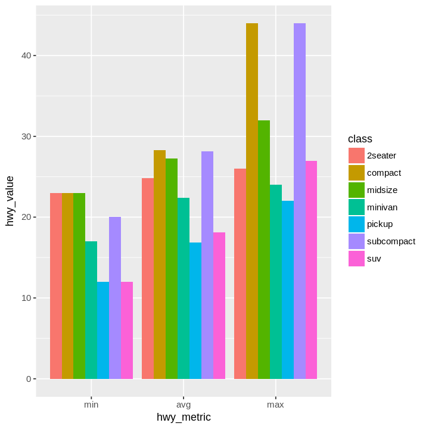

```r
# Plot min, max, and avg
# using geom_col()
# fill by class
# position = "dodge"
  options(repr.plot.width=6, repr.plot.height=6)

df4 %>%
   ggplot(aes(hwy_metric, hwy_value, fill = class)) +
      geom_col(position = "dodge")
```

Notice which class has the lowest average hwy mpg.

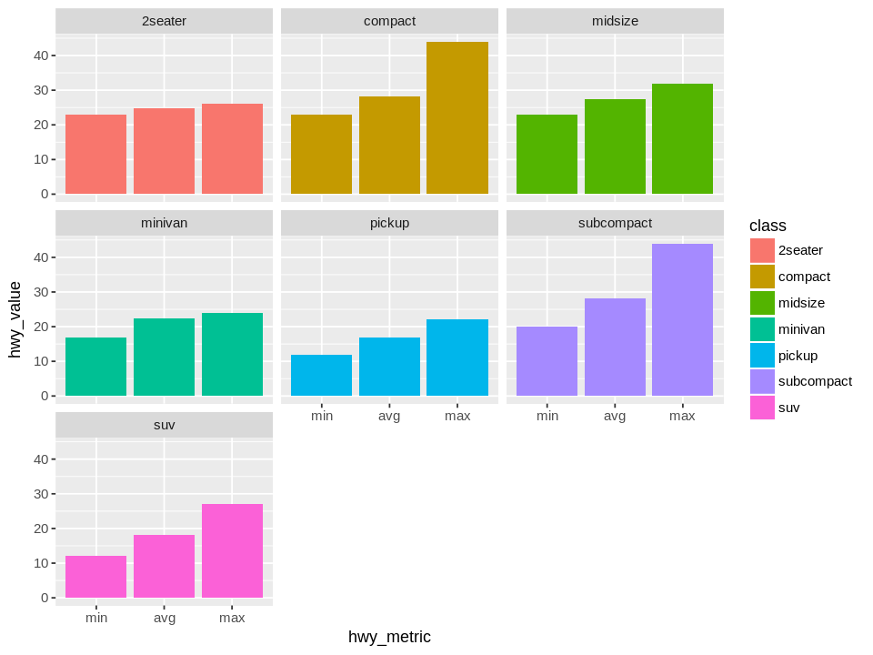

```r
# Plot min, max, and avg
# using geom_col()
# fill by class
# position = "dodge"
# facet by class
  options(repr.plot.width=8, repr.plot.height=6)

df4 %>%
   ggplot(aes(hwy_metric, hwy_value, fill = class)) +
      geom_col(position = "dodge") +
      facet_wrap( ~ class)
```

Notice how compact and sub compact have a larger delta from min to max. Also notice the 2seater, by contrast doesn't have much of a delta from min to max.

## Boxplot

Many common summaries such as min, mean, and max are built into ggplot and wouldn't require calculuating them in the data frame. A boxplot is a good visualization of the variance of a value. It is a bit more sophisticated than min, mean, and max, but conveys the information perhaps even better.

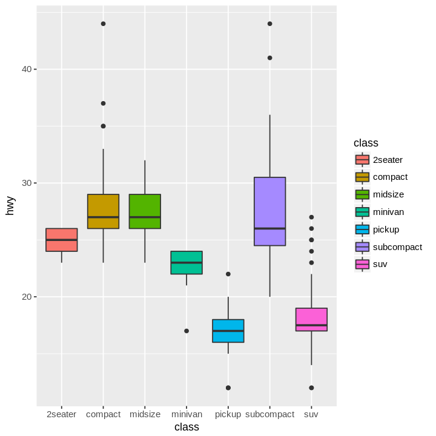

```r
# Create a box plot of
# mpg class and hwy
# fill by class
# Hint: geom_boxplot()
mpg %>%
   ggplot(aes(class, hwy, fill = class)) +
   geom_boxplot()

# "fill" colors inside and adds legend
```

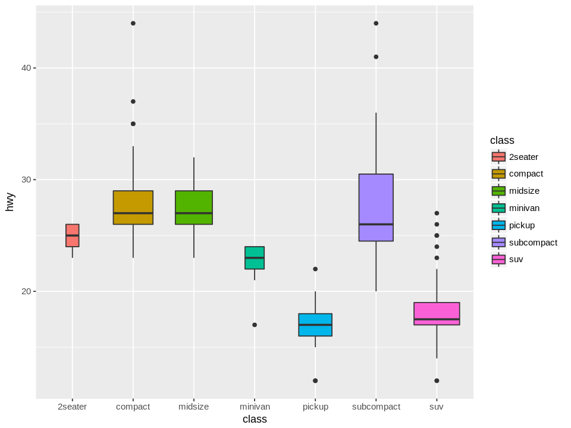

```r
# Create a box plot of
# mpg class and hwy
# fill by class
# varwidth = TRUE
mpg %>%
   ggplot(aes(class, hwy, fill = class)) +
   geom_boxplot(varwidth = TRUE)
```

Setting varwidth = TRUE for a boxplot changes the width of each box in proportion to the number of rows of that class. 2seater didn't have much variance in the data because there weren't that many 2seater vehicles in the data set. By contrast, there are a large number of suvs yet most have a hwy value in a similar range.

# Summary

The dplyr package contains a number of functions to help manipulate and group data. You used the generic group_by() then summarize() functions counting rows with n() as well as calculating summary statistics of min, mean, and max. You found that there were many convenience functions in dplyr. You used tally() and count(). You plotted the summarized results after using gather to move the stats columns to rows. Finally, you discovered that common stat functions are built into various ggplot geoms and explored the box plot. There will be many occasions to group data. You now have the tools to perform this task with ease.